# Exploring Programme for International Student Assessment (PISA) Data Trends

## by Shaheer Khan

## Investigation Overview

This presentation will discuss the key factors affecting students' overall literacy.

## Dataset Overview

The dataset being analyzed is gathered from PISA, which is a survey depicting students' skills and knowledge as they approach the end of compulsory education. It is not a conventional school test. This test focuses on how well prepared are students for life beyond school. Unlike many conventional tests which evaluate how well students have learned the school curriculum. The PISA test evaluates the more practical and real life scenario of a student's journey through life after school.

Around 510,000 students in 65 economies took part in the PISA 2012 assessment of reading, mathematics and science representing about 28 million 15-year-olds globally. Of those economies, 44 took part in an assessment of creative problem solving and 18 in an assessment of financial literacy.

### Variables Analyzed are:

- Grade - Grade compared to modal grade in country (Quantitative).
- Overall Literacy - *Engineered Variable* (Quantitative)
- Average Learning Time in mins per Week - *Engineered Variable* (Quantitative)
- Perseverance: Give up easily (Categorical)
- Internet Connection (Categorical)
- Highest educational level of parents (Categorical)
- Highest Parental Occupational Status (Quantitative)
- Grade Repeated (class repeated) (Categorical)

## Visualization 1A

In this plot, the variables investigated are shown below:

- Grade Repeated (Categorical)
- Count of Students (Quantitative)
- Internet Connection (Categorical)

Having 2 categorical and 1 Quantitative variables, a barplot is used. On the x-axis is the variable "Internet Connection" and on y-axis is the variable "Count of Students" and the color encoding representing "Grade Repeated" variable.

There are more number of students who repeated a grade given they have and use an internet connection compared to the students who either have internet connection but didn't use it or those who do not have internet connection altogether. This calls on to further investigate these variables but instead of the y-axis being the count variable I chose to use "Average Learning Time" variable to further explore a trend or a relationship worth discussing in the next plot (Visualization 1B).

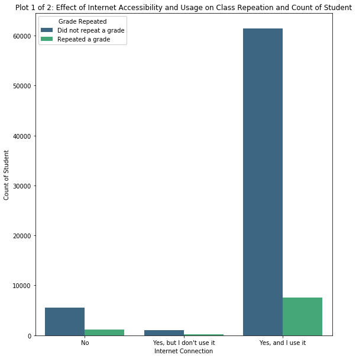

```python
plt.figure(figsize = [9, 10])
ax = sb.countplot(data = df_pisa_final, x = 'Internet_Connection', hue = 'Class_repeated', palette='viridis')
ax.legend(loc = 2, ncol = 1, framealpha = 1, title = 'Grade Repeated')
plt.title("Plot 1 of 2: Effect of Internet Accessibility and Usage on Class Repeation and Count of Student")
plt.xlabel('Internet Connection')
plt.ylabel('Count of Student');
```

## Visualization 1B

In this plot, the variables investigated are shown below:

- Grade Repeated (Categorical)
- Average Learning Time in mins per Week (Quantitative)
- Internet Connection (Categorical)

Having 2 categorical and 1 Quantitative variable, a barplot is used. On the x-axis is the variable "Internet Connection" and on y-axis is the variable "Average Learning Time" and the color encoding representing "Grade Repeated" variable.

Those students who had and used internet connection tend to have the least amount of average learning time regardless of having repeated or not repeated a grade in comparison to the students who either have internet connection but didn't use it or those who do not have internet connection altogether. Students who had no internet connection had spent on average more learning time compared to those students who had internet connection and do not use it or those who have internet connection and use it.

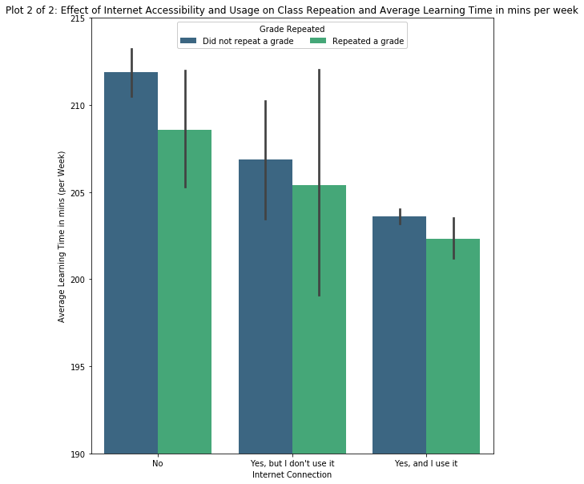

```python
plt.figure(figsize = [9, 10])
ax = sb.barplot(data = df_pisa_final, x = 'Internet_Connection', y = 'Average_Learning_Time', hue = 'Class_repeated', palette='viridis')
ax.legend(loc = 9, ncol = 3, framealpha = 1, title = "Grade Repeated")
ax.set_ylim([190,215]);
plt.title("Plot 2 of 2: Effect of Internet Accessibility and Usage on Class Repeation and Average Learning Time in mins per week")
plt.xlabel('Internet Connection')
plt.ylabel('Average Learning Time in mins (per Week)');
#plt.rcParams.update({'font.size': 10});
```

## Visualization 2

In this plot, the variables investigated are shown below:

- Grade Repeated (Categorical)
- Overall Literacy (Quantitative)
- Internet Connection (Categorical)

Having 2 categorical and 1 Quantitative variables, a boxplot is used. On the x-axis is the variable "Grade Repeated" and on y-axis is the variable "Overall Literacy" and with the 3 faceted boxplot having three options for the categorical variable called "Internet Connection".

As visible in the plot regardless of the students having repeated a class or not, they have higher overall literacy given they had internet connection and used it as compared to those who had internet connection but didn't use it or those who didn't have internet connection at all.

A surprising observation found here was that those students eventho had repeated a grade had a higher overall literacy given they had and used internet connection compared to students who repeated or not repeated a class given they either had no internet connection or they had internet connection but didnt use it.

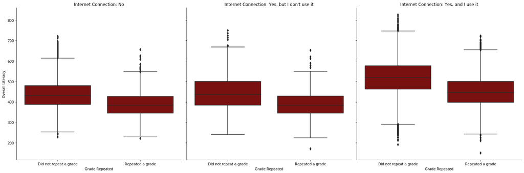

```python
g = sb.FacetGrid(data = df_pisa_final, col = 'Internet_Connection', size = 7, col_wrap=3)
g.map(sb.boxplot, 'Class_repeated', 'Overall_Literacy', color='darkred');
g.axes[0].set_xlabel('Grade Repeated')
g.axes[1].set_xlabel('Grade Repeated')
g.axes[2].set_xlabel('Grade Repeated')
g.axes[0].set_ylabel('Overall Literacy');
g.axes[0].set_title("Internet Connection: No");
g.axes[1].set_title("Internet Connection: Yes, but I don't use it");
g.axes[2].set_title("Internet Connection: Yes, and I use it");
```

## Visualization 3

In this plot, the variables investigated are shown below:

- Grade Repeated (Categorical)
- Overall Literacy (Quantitative)
- Highest Educational Level of Parents (Categorical)

Having 2 categorical and 1 Quantitative variables, a barplot would be the best fit for this type of setup. On the x-axis is the variable "Grade Repeated" and on y-axis is the variable "Overall Literacy" and with the color encoding on the right representing "Highest Educational Level of Parents" scale. As visible in the plot, students with parents' who have high education level tend to have higher overall literacy given those students did not repeat a grade. As for those students who did repeat a grade similar pattern is shown.

A surprising observation was found for students who did not repeat a grade; those students had higher overall literacy for whose parents had atleast an ISCED 3, ISCED 4 education level as compared to those parents who had ISCED 3B, C and even ISCED 5B level as shown in the plot below. Common logic says that as education level of parents increase so should the overall literacy of students but an uncommon observation was found as discussed earlier. Similar patterns can be found for the students who did repeat a grade but instead student whose parents had atleast an ISCED 3B education level have higher overall literacy than whose parents had ISCED 5B educationn level as shown in the plot below.

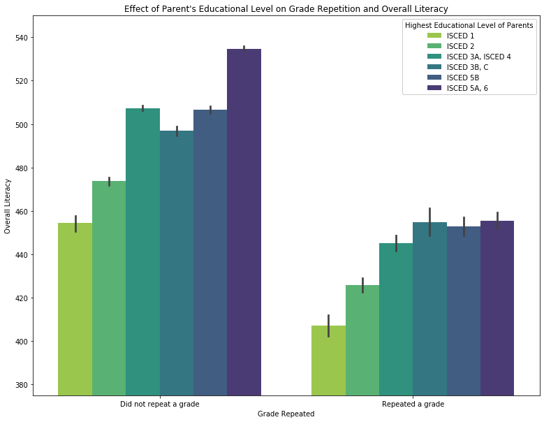

```python
plt.figure(figsize = [13, 10])
ax = sb.barplot(data = df_pisa_final, x = 'Class_repeated', y = 'Overall_Literacy', hue = 'Highest_educational_level_parents', palette='viridis_r')
ax.legend(loc = 1, ncol = 1, framealpha = 1, title = 'Highest Educational Level of Parents')
plt.title("Effect of Parent's Educational Level on Grade Repetition and Overall Literacy")
plt.xlabel('Grade Repeated')
plt.ylabel('Overall Literacy')
ax.set_ylim([375,550]);
```

## Visualization 4A

In this plot, the variables investigated are shown below:

- Grade Repeated (Categorical)
- Overall Literacy (Quantitative)
- Perseverance (Categorical)

Having 2 categorical and 1 Quantitative variables, a barplot would be the best fit for this type of setup. On the x-axis is the variable "Grade Repeated" and on y-axis is the variable "Overall Literacy" and with the color encoding on the right representing "Perseverance" scale.

As visible in the plot students who didn't give up easily tend to have the highest overall literacy given they didn't repeat a grade/class. For the students who repeated a grade, similar downwards staircase pattern is found from the left most bar to the right most bar depicting that as students give up easily the lower the overall literacy. This plot gives a way to investigating another relatioship that is to find out the count of students for the respective perseverance level and class repeated category (see Visualization 4B).

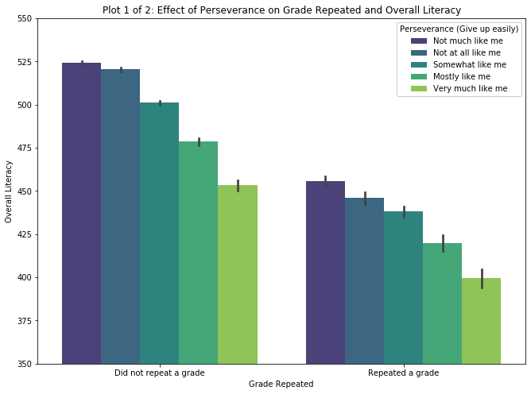

```python
plt.figure(figsize = [11, 8])
ax = sb.barplot(data = df_pisa_final, x = 'Class_repeated', y = 'Overall_Literacy', hue = 'Perseverance_Give_up_easily', palette='viridis')
ax.legend(loc = 1, ncol = 1, framealpha = 1, title = 'Perseverance (Give up easily)')
plt.title('Plot 1 of 2: Effect of Perseverance on Grade Repeated and Overall Literacy')
plt.xlabel('Grade Repeated')
plt.ylabel('Overall Literacy')
ax.set_ylim([350,550]);
```

## Visualization 4B

In this plot, the variables investigated are shown below:

- Grade Repeated (Categorical)
- Count of Students (Quantitative)
- Perseverance (Categorical)

Continuing from the previous visualization, this plot has the same configurations with the exception of the y-axis where this axis holds "Count of Students" variable.

There is an interesting observation, although normally you think those who are giving up easily must have repeated a grade/class. But as shown below as per the survey results, the count of students giving up easily given they repeated a grade is much less than those who give up easily given they didn't repeat a grade. To combat this irregular observation, I would suggest more data samples to be gathered and to evaluate this factor more thoroghly.

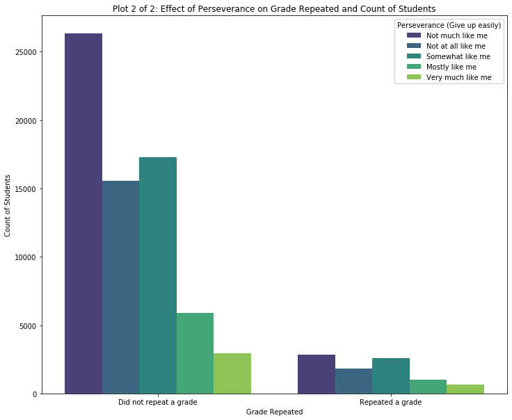

```python
plt.figure(figsize = [12, 10])
ax = sb.countplot(data = df_pisa_final, x = 'Class_repeated', hue = 'Perseverance_Give_up_easily', palette='viridis')
ax.legend(loc = 1, ncol = 1, framealpha = 1, title = 'Perseverance (Give up easily)');
plt.title('Plot 2 of 2: Effect of Perseverance on Grade Repeated and Count of Students');
plt.xlabel('Grade Repeated')
plt.ylabel('Count of Students');
```

## Visualization 5

In this plot, the variables investigated are shown below:

- Highest Parental Occupational Status (Quantitative)
- Overall Literacy (Quantitative)
- Grade (Quantitative)

Having 3 Quantitative variables, a scatter plot would be the best fit for this type of setup. Due to over sampling, random sample of the data was used. On the x-axis is the variable "Highest Parental Occupational Status" and on y-axis is the variable "Overall Literacy" and with the color encoded bar on the right representing "Grade". The variable Grade is compared to modal grade in country. The relative grade index (Grade) was computed to capture between-country variation. It indicates whether students are in the country’s a modal grade ie (value of 0) or whether they are below or above the modal grade (-x grades, +x grades).

As the Parents' occupational status increase so does the student's overall literacy, with that students' modal grades have stayed the same as the country's modal grade with few of the grades being above the modal grade. The right side of the plot has majority of students who are in the country’s modal grade if not above the modal grade. Whereas, as the parents' occupational status decrease so does the student's overall literacy, with that more and more students are below the modal grade.

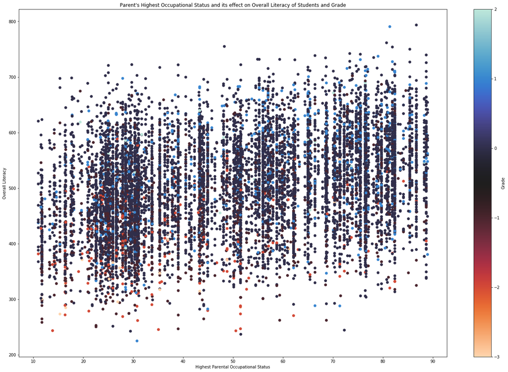

```python
plt.figure(figsize = [24, 16])
plt.scatter(data = df_trimmed, x = 'Highest_parental_occupational_status', y = 'Overall_Literacy', c = 'Grade',
            cmap = 'icefire_r', alpha=1)
plt.title("Parent's Highest Occupational Status and its effect on Overall Literacy of Students and Grade")
plt.xlabel('Highest Parental Occupational Status')
plt.ylabel('Overall Literacy')
plt.colorbar(label = 'Grade');
#mako_r
```

## Visualization 6

In this plot, the variables investigated are shown below:

- Highest Parental Occupational Status (Quantitative)
- Overall Literacy (Quantitative)
- Grade Repeated (Categorical)

Having 2 Quantitative and 1 Categorical variable, a scatter plot would be best fit for this type of setup. Due to over sampling, random sample of the data was used to better depict the trend on the plot. On the x-axis is the variable "Highest Parental Occupational Status" and on y-axis is the variable "Overall Literacy" and with the color encoding being "Grade Repeated".

As the Parents' occupational status increase so does the student's overall literacy, with that less and less students have repeated a class. The right side of the plot has majority of students who did not repeat a grade whereas, as the parents' occupational status decrease so does the student's overall literacy, with that more and more students repeated a grade.

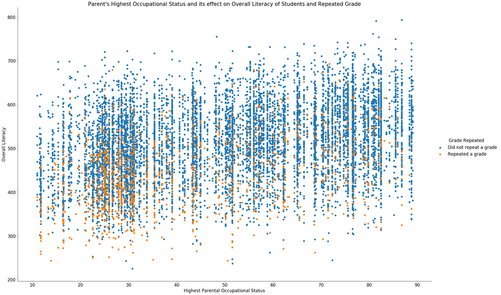

```python
g = sb.FacetGrid(data = df_trimmed, hue = 'Class_repeated', size = 16, aspect=1.5)
g.map(plt.scatter, 'Highest_parental_occupational_status', 'Overall_Literacy', alpha=1)
plt.title("Parent's Highest Occupational Status and its effect on Overall Literacy of Students and Repeated Grade")
plt.xlabel('Highest Parental Occupational Status')
plt.ylabel('Overall Literacy')
g.add_legend(title ='Grade Repeated');
plt.rcParams.update({'font.size': 17});
```

## Visualization 7

In this plot, the variables investigated are shown below:

- Highest Parental Occupational Status (Quantitative)
- Overall Literacy (Quantitative)
- Internet Connection (Categorical)

Having 2 Quantitative and 1 Categorical variable, a scatter plot would be the best fit for this type of setup. Due to over sampling, random sample of the data was used to better depict the trend on the plot. On the x-axis is the variable "Highest Parental Occupational Status" and on y-axis is the variable "Overall Literacy" and with the color encoding representing "Internet Connection".

As the Parents' occupational status increase so does the student's overall literacy, with that more and more students have access to internet. The right side of the plot has majority of students using internet whereas, as the parents' occupational status decrease so does the student's overall literacy, with that less and less students have access to internet.

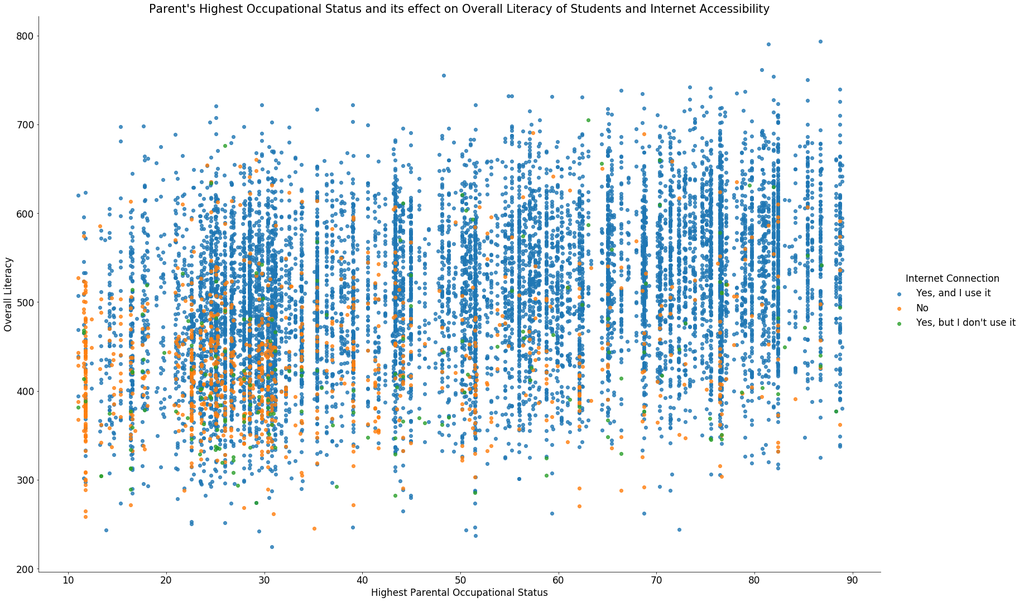

```python
g = sb.FacetGrid(data = df_trimmed, hue = 'Internet_Connection', size = 15, aspect=1.5)
g.map(plt.scatter, 'Highest_parental_occupational_status', 'Overall_Literacy', alpha=.8)
plt.title("Parent's Highest Occupational Status and its effect on Overall Literacy of Students and Internet Accessibility")
plt.xlabel('Highest Parental Occupational Status')
plt.ylabel('Overall Literacy')
g.add_legend(title ='Internet Connection');
```